# Лабораторная работа №4

Администрирование сетевых подсистем

Иванов Сергей Владимирович, НПИбд-01-23

Российский университет дружбы народов, Москва, Россия

23 сентября 2025

## Цель работы

Целью данной работы является приобретение практических навыков по установке и базовому конфигурированию HTTP-сервера Apache.

## Задание

1. Установите необходимые для работы HTTP-сервера пакеты (см. раздел 4.4.1).
2. Запустите HTTP-сервер с базовой конфигурацией и проанализируйте его работу (см. разделы 4.4.2 и 4.4.3).
3. Настройте виртуальный хостинг (см. раздел 4.4.4).
4. Напишите скрипт для Vagrant, фиксирующий действия по установке и настройке HTTP-сервера во внутреннем окружении виртуальной машины server. Соответствующим образом внесите изменения в Vagrantfile (см. раздел 4.4.5).

# Выполнение работы

## Установка HTTP-сервера

Загрузим операционную систему и перейдем в рабочий каталог с проектом. Запустим виртуальную машину server. (рис. 1).

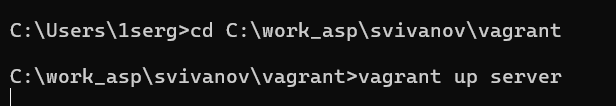

Запуск server

## Установка HTTP-сервера

На виртуальной машине server откроем терминал. Перейдем в режим суперпользователя. Установим http (рис. 2).

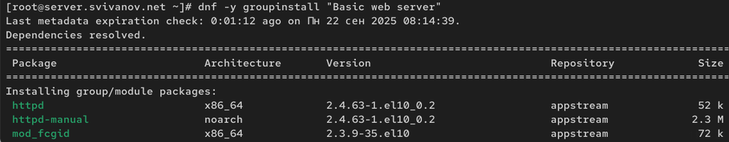

Установка http

## Базовое конфигурирование HTTP-сервера

Просмотрим содержание конфигурационных файлов в каталогах /etc/httpd/conf и /etc/httpd/conf.d.

## Базовое конфигурирование HTTP-сервера

Файл httpd.conf (рис. 3)

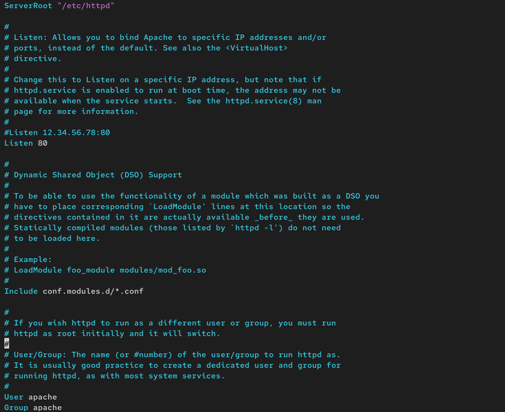

Файл httpd.conf

## Базовое конфигурирование HTTP-сервера

Файл autoindex.conf (рис. 4)

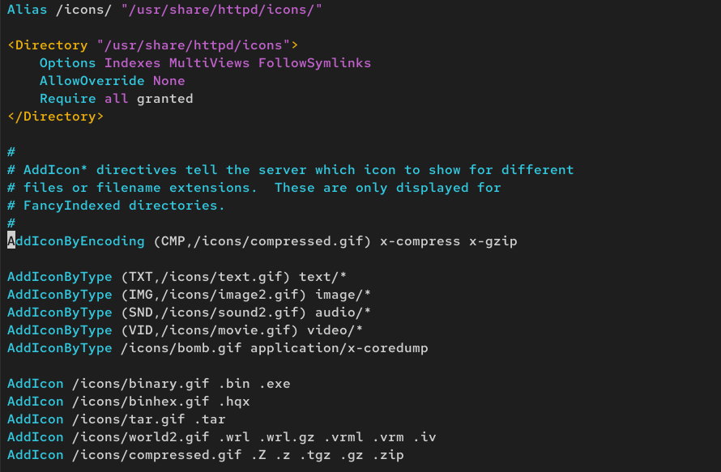

Файл autoindex.conf

## Базовое конфигурирование HTTP-сервера

Файл fcgid.conf (рис. 5)

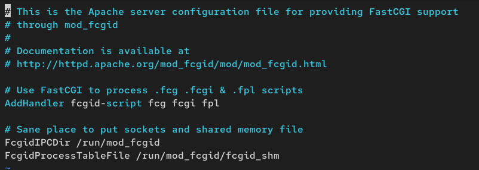

Файл fcgid.conf

## Базовое конфигурирование HTTP-сервера

Файл manual.conf (рис. 6)

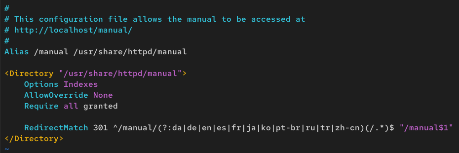

Файл manual.conf

## Базовое конфигурирование HTTP-сервера

Файл ssl.conf (рис. 7)

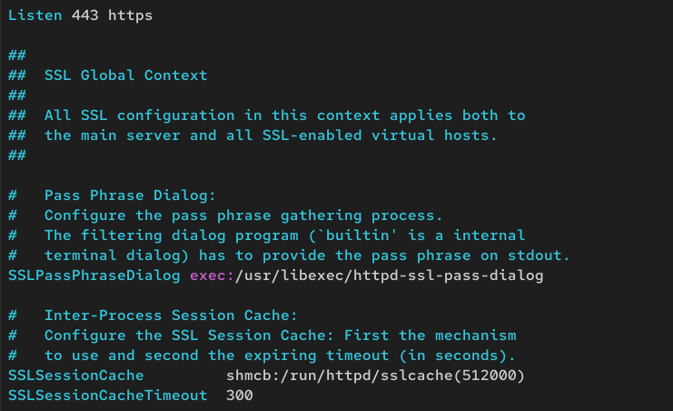

Файл ssl.conf

## Базовое конфигурирование HTTP-сервера

Файл userdir.conf (рис. 8)

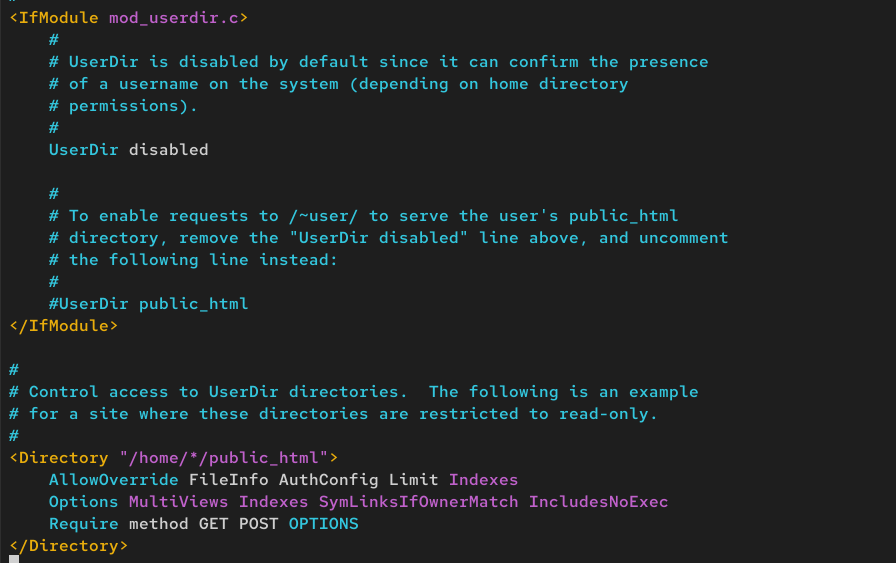

Файл userdir.conf

Файл welcome.conf (рис. 9)

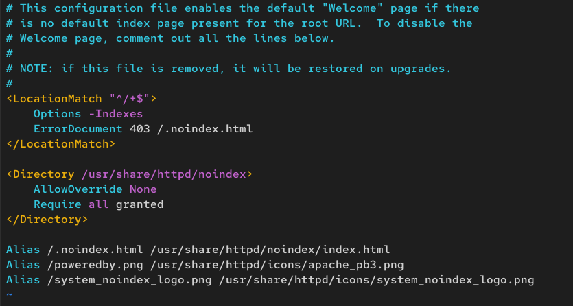

Редактирование файлов

Внесем изменения в настройки межсетевого экрана узла server, разрешив работу с http: (рис. 10)

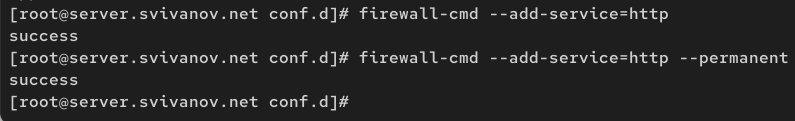

Изменения в настройках firewall

В дополнительном терминале запустим расширенный лог сообщений, чтобы проверить корректность работы системы. В первом терминале запустим HTTP-сервер. Просмотрев расширенный лог сообщений, убедимся, что веб-сервер успешно запустился (рис. 11)

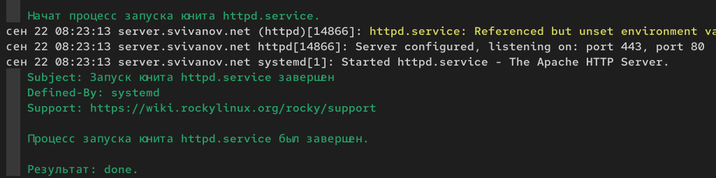

Запуск лога сообщений и запуск веб-сервера

## Анализ работы HTTP-сервера

Запустим виртуальную машину client. (рис. 12)

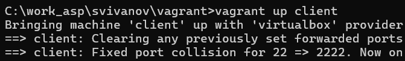

Запуск client

## Анализ работы HTTP-сервера

На виртуальной машине server просмотрим лог ошибок работы веб-сервера (рис. 13)

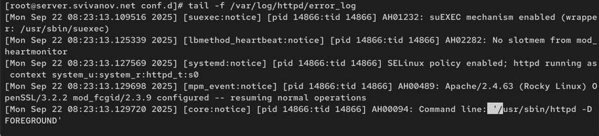

Запуск лога ошибок

## Анализ работы HTTP-сервера

На виртуальной машине server запустим мониторинг доступа к веб-серверу (рис. 14)

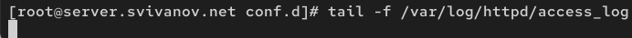

Запуск мониторинга доступа

## Анализ работы HTTP-сервера

На виртуальной машине client запустим браузер и в адресной строке введем 192.168.1.1 (рис. 15)

[figure not shown]

Подключение к серверу 192.168.1.1

## Анализ работы HTTP-сервера

Просмотрим информацию, отобразившуюся при мониторинге (рис. 16)

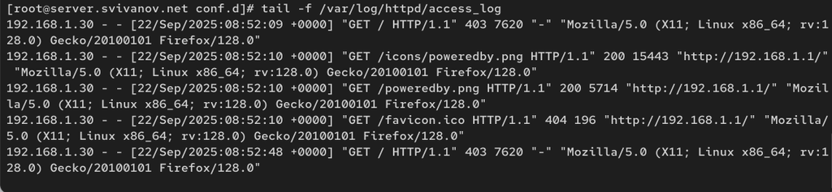

Мониторинг

## Настройка виртуального хостинга для HTTP-сервера

Остановим работу DNS-сервера для внесения изменений в файлы описания DNSзон. Добавим запись для HTTP-сервера в конце файла прямой DNS-зоны (рис. 17)

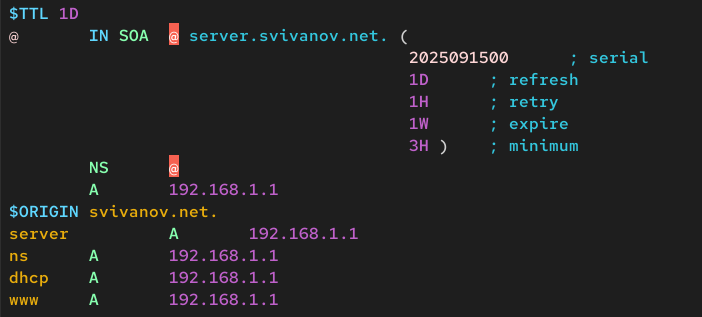

Добавление записи

## Настройка виртуального хостинга для HTTP-сервера

И в конце файла обратной зоны (рис. 18)

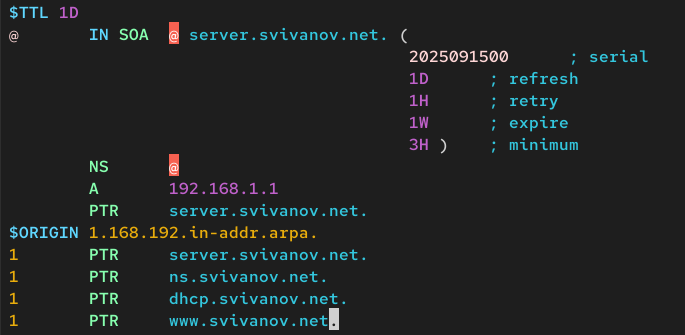

Добавление записи

## Настройка виртуального хостинга для HTTP-сервера

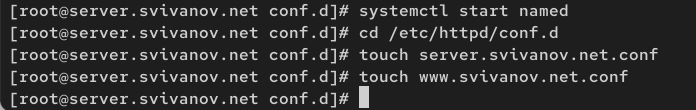

Перезапуск сервера и создание файлов

## Настройка виртуального хостинга для HTTP-сервера

Откроем на редактирование файл server.svivanov.net.conf и внесем следующее содержание: (рис. 20)

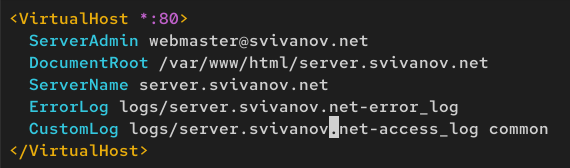

Редактирование конф. файла

## Настройка виртуального хостинга для HTTP-сервера

Откроем на редактирование файл www.svivanov.net.conf и внесем следующее содержание: (рис. 21)

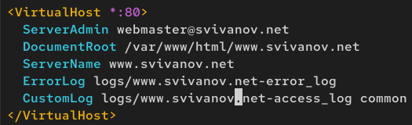

Редактирование конф. файла

## Настройка виртуального хостинга для HTTP-сервера

Открем на редактирование файл index.html и внесем следующее содержание (рис. 22)

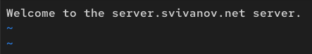

Редактирование index.html

## Настройка виртуального хостинга для HTTP-сервера

Для виртуального веб-сервера www.svivanov.net: (рис. 23)

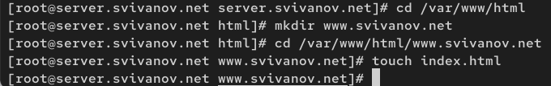

Создание файлов и папок

## Настройка виртуального хостинга для HTTP-сервера

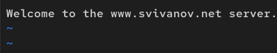

Редактирование index.html

## Настройка виртуального хостинга для HTTP-сервера

Скорректируем права доступа в каталог с веб-контентом. Восстановим контекст безопасности в SELinux. Перезапустим HTTP-сервер: (рис. 25)

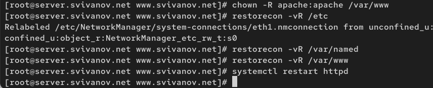

Восстановление меток и перезапуск сервера

## Настройка виртуального хостинга для HTTP-сервера

На виртуальной машине client убедимся в корректном доступе к веб-серверу по адресам server.svivanov.net и www.svivanov.net в адресной строке веб-браузера. (рис. 26, 27)

[figure not shown]

Доступ к веб-серверу в адресной строке

## Настройка виртуального хостинга для HTTP-сервера

[figure not shown]

Доступ к веб-серверу в адресной строке

## Внесение изменений в настройки внутреннего окружения виртуальной машины

На виртуальной машине server перейдем в каталог для внесения изменений в настройки внутреннего окружения /vagrant/provision/server/, создадим в нём каталог http, в который поместим в соответствующие подкаталоги конфигурационные файлы HTTP-сервера (рис. 28)

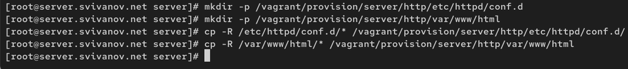

Создание каталогов и копирование файлов

## Внесение изменений в настройки внутреннего окружения виртуальной машины

Заменим конфигурационные файлы DNS-сервера (рис. 29)

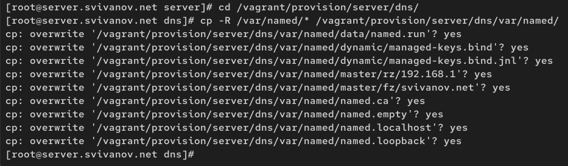

Замена конф. файлов

## Внесение изменений в настройки внутреннего окружения виртуальной машины

В каталоге /vagrant/provision/server создадим исполняемый файл http.sh. Открыв его на редактирование, пропишем в нём скрипт: (рис. 30)

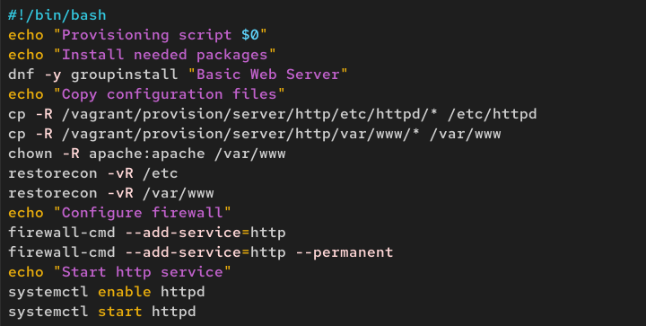

Создание скрипта

## Внесение изменений в настройки внутреннего окружения виртуальной машины

Для отработки созданного скрипта во время загрузки виртуальных машин в файле Vagrantfile добавим в конфигурации сервера следующую запись: (рис. 31)

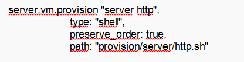

Редактирование Vagrantfile

# Вывод

## Вывод

В ходе выполнения лабораторной работы мы приобрели практическиt навыки по установке и базовому конфигурированию HTTP-сервера Apache.